# Reading and Tidying Data

## Getting started with pandas

Pandas is a powerful and widely used library in Python for data manipulation and analysis. It provides versatile data structures, such as DataFrames and Series, along with a variety of functions and methods for efficiently handling and processing structured data. In this session, we explore some functionalities of Pandas library that is useful for biological data analysis.

Customarily, we import the library as follows:

```python
import pandas as pd
```

## Basic data structures in pandas

Pandas provides two types of classes for handling data: **`Series`** and **`DataFrame`**.

### Series

`Series` is a one-dimensional labeled array capable of holding any data type (integers, strings, floating point numbers, Python objects, etc.). The axis labels are collectively referred to as the index. The basic method to create a `Series` is to call:

```python
s = pd.Series(data, index=index)
```

Here, **data** can be a Python dict, an ndarray (a multidimensional container of items of the same type and size) or a scalar value. The passed **index** is a list of axis labels.

#### Using a list:

```python
s1 = pd.Series([1, 3, 5, 6, 8])
s1
```

```
0    1
1    3
2    5
3    6
4    8
dtype: int64
```

#### Using a scalar (single value):

```python
s2 = pd.Series(5.0, index=["a", "b", "c", "d", "e"])
s2
```

```
a    5.0
b    5.0
c    5.0
d    5.0
e    5.0
dtype: float64
```

#### Using a numpy array:

To create a `Series` using ndarray first import numpy library.

```python
import numpy as np
```

NumPy, short for Numerical Python, is a fundamental Python library for scientific computing. It provides support for working with large, multi-dimensional arrays and matrices, as well as a collection of high-level mathematical functions to operate on these arrays.

```python
s3 = pd.Series(np.random.randn(5), index=["a", "b", "c", "d", "e"])
s3
```

```
a   -0.587588
b    1.196789
c   -0.842176
d   -1.345223
e    0.083993
dtype: float64
```

The np.random module in NumPy is designed for generating pseudo-random numbers, enabling you to extract samples from a wide range of probability distributions. Specifically, the np.random.randn function is used to obtain one or more samples from the “standard normal” distribution, characterized by a mean of 0 and a variance of 1.

If data is an ndarray, index must be the same length as data. If no index is passed, one will be created having values [0, …, len(data) - 1].

```python
s3 = pd.Series(np.random.randn(5))
s3
```

```
0    2.071941
1   -2.126020
2   -1.403105
3    0.904217
4   -0.019960
dtype: float64
```

#### Using a dictionary:

`Series` can be instantiated from dicts (recall dictionary from last week) as follows:

```python
d = {"A": 248, "C": 243, "G": 266, "T": 243}
s4 = pd.Series(d)
s4
```

```
A    248
C    243
G    266
T    243
dtype: int64
```

```python
s4 = pd.Series(dict, index=["A", "B", "C"])
s4
```

```
A    <class 'dict'>
B    <class 'dict'>
C    <class 'dict'>
dtype: object
```

### DataFrame

`DataFrame` is a 2-dimensional labeled data structure with columns of potentially different types. You can think of it like a spreadsheet or SQL table, or a dict of Series objects. The `DataFrame` is generally the most commonly used pandas object. It accepts many different types of input including dictionary of 1-D ndarrays, lists, dictionaries or Series, 2-D ndarray, a Series or even another DataFrame.

Along with the data, you can optionally pass index (row labels) and columns (column labels) arguments. If you pass an index and/or columns, you are guaranteeing the index and/or columns of the resulting DataFrame.

The basic method to create a `DataFrame` is to call:

```python
df = pd.DataFrame(data, index=index, columns=columns)
```

#### Creating a `DataFrame` by using a dictionary of `Series`:

```python
# a dictionary of series
d = {
    "Col 1": pd.Series([1.0, 2.0, 3.0], index=["a", "b", "c"]),
    "Col 2": pd.Series([1.0, 2.0, 3.0, 4.0], index=["a", "b", "c", "d"]),
}
df1 = pd.DataFrame(d)
df1
```

|  | Col 1 | Col 2 |
| --- | --- | --- |
| a | 1.0 | 1.0 |
| b | 2.0 | 2.0 |
| c | 3.0 | 3.0 |
| d | NaN | 4.0 |

```python
# table with rows: d, b  and a of the above dictionary
df2 = pd.DataFrame(d, index=["d", "b", "a"])
df2
```

|  | Col 1 | Col 2 |
| --- | --- | --- |
| d | NaN | 4.0 |
| b | 2.0 | 2.0 |
| a | 1.0 | 1.0 |

Note: **NaN**, standing for **not a number**, is a numeric data type used to represent any value that is undefined. It is by default not included in computations.

#### Creating a `DataFrame` by using a dictionary of `Series`, lists, ndarrays:

```python
# a dictionary
data = {
    'Name': ['Alice', 'Bob', 'Charlie', 'David'],
    'Age': pd.Series([25, 30, 35, 40]),
    'City': ['New York', 'Los Angeles', 'Chicago', 'Houston'],
    'Salary': np.array([50000, 60000, 75000, 90000])
}

df3 = pd.DataFrame(data)
df3
```

|  | Name | Age | City | Salary |
| --- | --- | --- | --- | --- |
| 0 | Alice | 25 | New York | 50000 |
| 1 | Bob | 30 | Los Angeles | 60000 |
| 2 | Charlie | 35 | Chicago | 75000 |
| 3 | David | 40 | Houston | 90000 |

### Indexes and Columns of `DataFrames`

Consider the following DataFrame,

```python
d = {"one": [1.0, 2.0, 3.0, 4.0], "two": [4.0, 3.0, 2.0, 1.0]}
df3 = pd.DataFrame(d, index=["a", "b", "c", "d"])
df3
```

|  | one | two |
| --- | --- | --- |
| a | 1.0 | 4.0 |
| b | 2.0 | 3.0 |
| c | 3.0 | 2.0 |
| d | 4.0 | 1.0 |

To print and update row names:

```python
df3.index = ["row 1", "row 2", "row 3", "row 4"]
df3
```

|  | one | two |
| --- | --- | --- |
| row 1 | 1.0 | 4.0 |
| row 2 | 2.0 | 3.0 |
| row 3 | 3.0 | 2.0 |
| row 4 | 4.0 | 1.0 |

To print and update column names:

```python
df3.columns = ["Column 1", "Column 2"]
df3
```

|  | Column 1 | Column 2 |
| --- | --- | --- |
| row 1 | 1.0 | 4.0 |
| row 2 | 2.0 | 3.0 |
| row 3 | 3.0 | 2.0 |
| row 4 | 4.0 | 1.0 |

To print the data type of each column:

```python
df = pd.DataFrame(
    {
        "A": np.random.uniform(low=0, high=1, size=12),
        "B": pd.date_range(start="20230102", periods=12),
        "C": pd.Series(range(1, 13), index=["R1", "R2", "R3", "R4", "R5", "R6", "R7", "R8" ,"R9", "R10", "R11", "R12"]),
        "D": np.random.randint(1, high=100, size=12),
        "E": pd.Categorical(["red", "green", "blue", "white", "pink", "brown", "black", "purple", "orange", "grey", "violet", "yellow"]),
        "F": "foo",
    }, index = ["R1", "R2", "R3", "R4", "R5", "R6", "R7", "R8" ,"R9", "R10", "R11", "R12"]
)
print(df.dtypes)
```

```
A           float64
B    datetime64[ns]
C             int64
D             int64
E          category
F            object
dtype: object
```

## Reading and Writing to a file

Up to this point, all the data we’ve been dealing with has been manually entered into our scripts, and the outcomes of our computations have simply been displayed in the terminal. However, in the real world, data will typically be provided by the users of our programs (which could include you!), and we often need to store the results of our analyses in a more permanent location than just printing them to the screen. During this session, we’ll explore a few commonly used methods for importing data into our programs by reading/writing files from disk using the pandas library.

It’s worth noting that there are numerous other ways to access data, such as querying a database or retrieving data from a network, such as the internet. While we won’t cover these methods in this session, Python offers excellent support for interacting with databases and networks, either through its standard library or via external modules.

### Comma-Seperated Values (CSV) file or Text file

Read a CSV or text file:

```python
pd.read_csv("path_to_file.csv")

# read a text file with values separated by spaces
pd.read_csv("path_to_file.txt", delimeter=' ')
```

Write a DataFrame `df` to a CSV or text file:

```python
df.to_csv("path_to_file.csv")
df.to_csv("path_to_file.txt")
```

### Excel file

Read an excel file:

```python
pd.read_excel("path_to_file.xls", sheet_name="Sheet1")
pd.read_excel("path/to/file/name/file_name.csv")
```

Write a DataFrame `df` to an excel file:

```python
df.to_excel("path_to_file.xlsx", sheet_name="Sheet1")
```

#### Challenge

**Read the CSV file associated with the Metabric dataset from this link into a Pandas DataFrame named `metabric`: “https://zenodo.org/record/6450144/files/metabric_clinical_and_expression_data.csv”.**

**Solution**

```python
import pandas as pd

# Load the Metabric dataset from the URL into a DataFrame
metabric = pd.read_csv("https://zenodo.org/record/6450144/files/metabric_clinical_and_expression_data.csv")
```

## Viewing data

Use `DataFrame.head()` to view the top rows of the DataFrame. It returns the top 5 rows of the DataFrame.

```python
df.head()
```

|  | A | B | C | D | E | F |
| --- | --- | --- | --- | --- | --- | --- |
| R1 | 0.151954 | 2023-01-02 | 1 | 62 | red | foo |
| R2 | 0.795155 | 2023-01-03 | 2 | 51 | green | foo |
| R3 | 0.466811 | 2023-01-04 | 3 | 76 | blue | foo |
| R4 | 0.574135 | 2023-01-05 | 4 | 26 | white | foo |
| R5 | 0.371566 | 2023-01-06 | 5 | 76 | pink | foo |

`DataFrame.tail()` shows the last 5 rows of the DataFrame.

```python
df.tail()
```

|  | A | B | C | D | E | F |
| --- | --- | --- | --- | --- | --- | --- |
| R8 | 0.791305 | 2023-01-09 | 8 | 15 | purple | foo |
| R9 | 0.662386 | 2023-01-10 | 9 | 27 | orange | foo |
| R10 | 0.519865 | 2023-01-11 | 10 | 99 | grey | foo |
| R11 | 0.234616 | 2023-01-12 | 11 | 70 | violet | foo |
| R12 | 0.571739 | 2023-01-13 | 12 | 46 | yellow | foo |

`DataFrame.index` returns the index (row labels) of the DataFrame.

```python
df.index
```

```
Index(['R1', 'R2', 'R3', 'R4', 'R5', 'R6', 'R7', 'R8', 'R9', 'R10', 'R11',
       'R12'],
      dtype='object')
```

`DataFrame.columns` returns the column names of the DataFrame.

```python
df.columns
```

```
Index(['A', 'B', 'C', 'D', 'E', 'F'], dtype='object')
```

- `DataFrame.dtypes` shows the data type of each column in the DataFrame, allowing you to understand what kind of data each column holds (e.g., integers, floats, or strings).

```python
df.dtypes
```

```
A           float64
B    datetime64[ns]
C             int64
D             int64
E          category
F            object
dtype: object
```

To get the **shape** of the DataFrame (i.e., the number of rows and columns), use:

```python
df.shape
```

```
(12, 6)
```

To get the **dimensions** of the DataFrame (i.e., the number of axes: rows and columns), use:

```python
df.ndim
```

```
2
```

To get the number of **rows** in the DataFrame, use:

```python
df.shape[0]
```

```
12
```

To get the number of **columns** in the DataFrame, use:

```python
df.shape[1]
```

```
6
```

To get a NumPy representation of the underlying data without the index or column labels, use:

```python
df.to_numpy()
```

```
array([[0.15195443597751745, Timestamp('2023-01-02 00:00:00'), 1, 62,
        'red', 'foo'],
       [0.7951553702291032, Timestamp('2023-01-03 00:00:00'), 2, 51,
        'green', 'foo'],
       [0.46681095942993434, Timestamp('2023-01-04 00:00:00'), 3, 76,
        'blue', 'foo'],
       [0.5741354104822484, Timestamp('2023-01-05 00:00:00'), 4, 26,
        'white', 'foo'],
       [0.37156604699239415, Timestamp('2023-01-06 00:00:00'), 5, 76,
        'pink', 'foo'],
       [0.25520143635087644, Timestamp('2023-01-07 00:00:00'), 6, 2,
        'brown', 'foo'],
       [0.3395384944321638, Timestamp('2023-01-08 00:00:00'), 7, 7,
        'black', 'foo'],
       [0.7913047723107759, Timestamp('2023-01-09 00:00:00'), 8, 15,
        'purple', 'foo'],
       [0.6623860740181179, Timestamp('2023-01-10 00:00:00'), 9, 27,
        'orange', 'foo'],
       [0.5198649589118002, Timestamp('2023-01-11 00:00:00'), 10, 99,
        'grey', 'foo'],
       [0.23461602524857528, Timestamp('2023-01-12 00:00:00'), 11, 70,
        'violet', 'foo'],
       [0.5717394479781833, Timestamp('2023-01-13 00:00:00'), 12, 46,
        'yellow', 'foo']], dtype=object)
```

`DataFrame.describe()` provides a quick statistical summary of the data. This summary includes:

- **count**: The number of rows for each column.
- **mean**: The average value for each numerical column.
- **std**: The standard deviation, which measures how spread out the values are.
- **min**: The minimum value for each column.
- **percentiles**: Includes the 25th, 50th (median), and 75th percentiles, also known as the 1st, 2nd, and 3rd quartiles.
- **max**: The maximum value in each column.

```python
df.describe()
```

|  | A | B | C | D |
| --- | --- | --- | --- | --- |
| count | 12.000000 | 12 | 12.000000 | 12.000000 |
| mean | 0.477856 | 2023-01-07 12:00:00 | 6.500000 | 46.416667 |
| min | 0.151954 | 2023-01-02 00:00:00 | 1.000000 | 2.000000 |
| 25% | 0.318454 | 2023-01-04 18:00:00 | 3.750000 | 23.250000 |
| 50% | 0.493338 | 2023-01-07 12:00:00 | 6.500000 | 48.500000 |
| 75% | 0.596198 | 2023-01-10 06:00:00 | 9.250000 | 71.500000 |
| max | 0.795155 | 2023-01-13 00:00:00 | 12.000000 | 99.000000 |
| std | 0.212845 | NaN | 3.605551 | 31.105271 |

The `DataFrame.info()` method provides a concise summary of the DataFrame’s structure. It is particularly useful for quickly inspecting the basic details of a DataFrame, such as its index, column names, data types, and memory usage.

```python
df.info()
```

```
<class 'pandas.core.frame.DataFrame'>
Index: 12 entries, R1 to R12
Data columns (total 6 columns):
 #   Column  Non-Null Count  Dtype
---  ------  --------------  -----
 0   A       12 non-null     float64
 1   B       12 non-null     datetime64[ns]
 2   C       12 non-null     int64
 3   D       12 non-null     int64
 4   E       12 non-null     category
 5   F       12 non-null     object
dtypes: category(1), datetime64[ns](1), float64(1), int64(2), object(1)
memory usage: 984.0+ bytes
```

`DataFrame.t` transpose your data. This results in a DataFrame where the columns of the DataFrame are now rows and the rows are now columns.

```python
df.T
```

|  | R1 | R2 | R3 | R4 | R5 | R6 | R7 | R8 | R9 | R10 | R11 | R12 |
| --- | --- | --- | --- | --- | --- | --- | --- | --- | --- | --- | --- | --- |
| A | 0.151954 | 0.795155 | 0.466811 | 0.574135 | 0.371566 | 0.255201 | 0.339538 | 0.791305 | 0.662386 | 0.519865 | 0.234616 | 0.571739 |
| B | 2023-01-02 00:00:00 | 2023-01-03 00:00:00 | 2023-01-04 00:00:00 | 2023-01-05 00:00:00 | 2023-01-06 00:00:00 | 2023-01-07 00:00:00 | 2023-01-08 00:00:00 | 2023-01-09 00:00:00 | 2023-01-10 00:00:00 | 2023-01-11 00:00:00 | 2023-01-12 00:00:00 | 2023-01-13 00:00:00 |
| C | 1 | 2 | 3 | 4 | 5 | 6 | 7 | 8 | 9 | 10 | 11 | 12 |
| D | 62 | 51 | 76 | 26 | 76 | 2 | 7 | 15 | 27 | 99 | 70 | 46 |
| E | red | green | blue | white | pink | brown | black | purple | orange | grey | violet | yellow |
| F | foo | foo | foo | foo | foo | foo | foo | foo | foo | foo | foo | foo |

`DataFrame.sort_index()` sorts by an axis. If no arguments are provided to this function, it restore to default value where `axis = 0` (same as `axis = 'index'`) (rows).`axis = 1` (same as `axis = 'columns'`) argument sort based on columns. This sorts the column labels rather than values in the table. This function accepts another argument called `ascending` which takes a boolean value (True or False).

```python
df.sort_index(axis=1, ascending=False)
```

|  | F | E | D | C | B | A |
| --- | --- | --- | --- | --- | --- | --- |
| R1 | foo | red | 62 | 1 | 2023-01-02 | 0.151954 |
| R2 | foo | green | 51 | 2 | 2023-01-03 | 0.795155 |
| R3 | foo | blue | 76 | 3 | 2023-01-04 | 0.466811 |
| R4 | foo | white | 26 | 4 | 2023-01-05 | 0.574135 |
| R5 | foo | pink | 76 | 5 | 2023-01-06 | 0.371566 |
| R6 | foo | brown | 2 | 6 | 2023-01-07 | 0.255201 |
| R7 | foo | black | 7 | 7 | 2023-01-08 | 0.339538 |
| R8 | foo | purple | 15 | 8 | 2023-01-09 | 0.791305 |
| R9 | foo | orange | 27 | 9 | 2023-01-10 | 0.662386 |
| R10 | foo | grey | 99 | 10 | 2023-01-11 | 0.519865 |
| R11 | foo | violet | 70 | 11 | 2023-01-12 | 0.234616 |
| R12 | foo | yellow | 46 | 12 | 2023-01-13 | 0.571739 |

`DataFrame.sort_values()` sorts based on columns. The by argument takes a name or list of column names to sort the DataFrame.

```python
df.sort_values(by="E")
```

|  | A | B | C | D | E | F |
| --- | --- | --- | --- | --- | --- | --- |
| R7 | 0.339538 | 2023-01-08 | 7 | 7 | black | foo |
| R3 | 0.466811 | 2023-01-04 | 3 | 76 | blue | foo |
| R6 | 0.255201 | 2023-01-07 | 6 | 2 | brown | foo |
| R2 | 0.795155 | 2023-01-03 | 2 | 51 | green | foo |
| R10 | 0.519865 | 2023-01-11 | 10 | 99 | grey | foo |
| R9 | 0.662386 | 2023-01-10 | 9 | 27 | orange | foo |
| R5 | 0.371566 | 2023-01-06 | 5 | 76 | pink | foo |
| R8 | 0.791305 | 2023-01-09 | 8 | 15 | purple | foo |
| R1 | 0.151954 | 2023-01-02 | 1 | 62 | red | foo |
| R11 | 0.234616 | 2023-01-12 | 11 | 70 | violet | foo |
| R4 | 0.574135 | 2023-01-05 | 4 | 26 | white | foo |
| R12 | 0.571739 | 2023-01-13 | 12 | 46 | yellow | foo |

#### Challenge

1. Print the top 5 and the bottom 5 rows of the `metabric` dataset.
2. Provide a high-level overview of the content and then display the content of the `metabric` dataset.
3. What is the number of rows and columns in the dataset?
4. Sort the dataset based on the `age_at_diagnosis` column.
5. Sort the dataset based on the `Survival_time` column.

**Solution**

```python
# Print the top 5 rows of the `metabric` dataset
metabric.head()

# Print the bottom 5 rows of the `metabric` dataset
metabric.tail()

# high-level overview of the content
metabric.info()
metabric.describe()

# Print the no. of rows (records) and columns (features) in the `metabric` dataset
metabric.shape
# print number of rows only
df.shape[0]
# print number of columns only
df.shape[1]

# Sort based on the `age_at_diagnosis` column
df.sort_values("age_at_diagnosis)

# Sort based on the `Survival_time` column
df.sort_values("Survival_time)
```

## Selecting data

### Selecting based on labels

`DataFrame.loc()` is used to retrieve a group of rows and/or columns by labels in the DataFrame.

- Selecting a row:

```python
df.loc["R5"]
```

```
A               0.371566
B    2023-01-06 00:00:00
C                      5
D                     76
E                   pink
F                    foo
Name: R5, dtype: object
```

- Selecting a range of rows:

```python
df.loc[["R1", "R2", "R5"]]
```

|  | A | B | C | D | E | F |
| --- | --- | --- | --- | --- | --- | --- |
| R1 | 0.151954 | 2023-01-02 | 1 | 62 | red | foo |
| R2 | 0.795155 | 2023-01-03 | 2 | 51 | green | foo |
| R5 | 0.371566 | 2023-01-06 | 5 | 76 | pink | foo |

```python
df.loc["R2":"R4"]
```

|  | A | B | C | D | E | F |
| --- | --- | --- | --- | --- | --- | --- |
| R2 | 0.795155 | 2023-01-03 | 2 | 51 | green | foo |
| R3 | 0.466811 | 2023-01-04 | 3 | 76 | blue | foo |
| R4 | 0.574135 | 2023-01-05 | 4 | 26 | white | foo |

- Selecting a column:

```python
df.loc[:, "E"]
```

```
R1        red
R2      green
R3       blue
R4      white
R5       pink
R6      brown
R7      black
R8     purple
R9     orange
R10      grey
R11    violet
R12    yellow
Name: E, dtype: category
Categories (12, object): ['black', 'blue', 'brown', 'green', ..., 'red', 'violet', 'white', 'yellow']
```

- Selecting a range of columns:

```python
df.loc[:, ["A","C"]]
```

|  | A | C |
| --- | --- | --- |
| R1 | 0.151954 | 1 |
| R2 | 0.795155 | 2 |
| R3 | 0.466811 | 3 |
| R4 | 0.574135 | 4 |
| R5 | 0.371566 | 5 |
| R6 | 0.255201 | 6 |
| R7 | 0.339538 | 7 |
| R8 | 0.791305 | 8 |
| R9 | 0.662386 | 9 |
| R10 | 0.519865 | 10 |
| R11 | 0.234616 | 11 |
| R12 | 0.571739 | 12 |

```python
df.loc[:, "D":"F"]
```

|  | D | E | F |
| --- | --- | --- | --- |
| R1 | 62 | red | foo |
| R2 | 51 | green | foo |
| R3 | 76 | blue | foo |
| R4 | 26 | white | foo |
| R5 | 76 | pink | foo |
| R6 | 2 | brown | foo |
| R7 | 7 | black | foo |
| R8 | 15 | purple | foo |
| R9 | 27 | orange | foo |
| R10 | 99 | grey | foo |
| R11 | 70 | violet | foo |
| R12 | 46 | yellow | foo |

- Selecting a row and a column:

```python
df.loc["R5", "A"]
```

```
0.37156604699239415
```

- Selecting a range of rows and columns:

```python
df.loc["R3":"R5", "D":"F"]
```

|  | D | E | F |
| --- | --- | --- | --- |
| R3 | 76 | blue | foo |
| R4 | 26 | white | foo |
| R5 | 76 | pink | foo |

```python
df.loc[["R3","R2"], ["B","D","F"]]
```

|  | B | D | F |
| --- | --- | --- | --- |
| R3 | 2023-01-04 | 76 | foo |
| R2 | 2023-01-03 | 51 | foo |

- Selecting a scalar using `DataFrame.at()` function:

```python
df.at["R1", "A"]
```

```
0.15195443597751745
```

### Selecting based on integer positions

`DataFrame.iloc()` is used to retrieve a group of rows and/or columns by integer position in the DataFrame. Note: integer position range from 0 to length-1 of rows or columns.

- Selecting a row:

```python
df.iloc[4]
```

```
A               0.371566
B    2023-01-06 00:00:00
C                      5
D                     76
E                   pink
F                    foo
Name: R5, dtype: object
```

- Selecting a range of rows:

```python
df.iloc[[0, 1, 4]]
```

|  | A | B | C | D | E | F |
| --- | --- | --- | --- | --- | --- | --- |
| R1 | 0.151954 | 2023-01-02 | 1 | 62 | red | foo |
| R2 | 0.795155 | 2023-01-03 | 2 | 51 | green | foo |
| R5 | 0.371566 | 2023-01-06 | 5 | 76 | pink | foo |

```python
df.iloc[2:6]
```

|  | A | B | C | D | E | F |
| --- | --- | --- | --- | --- | --- | --- |
| R3 | 0.466811 | 2023-01-04 | 3 | 76 | blue | foo |
| R4 | 0.574135 | 2023-01-05 | 4 | 26 | white | foo |
| R5 | 0.371566 | 2023-01-06 | 5 | 76 | pink | foo |
| R6 | 0.255201 | 2023-01-07 | 6 | 2 | brown | foo |

Select top 3 rows

```python
df.iloc[:3]
```

|  | A | B | C | D | E | F |
| --- | --- | --- | --- | --- | --- | --- |
| R1 | 0.151954 | 2023-01-02 | 1 | 62 | red | foo |
| R2 | 0.795155 | 2023-01-03 | 2 | 51 | green | foo |
| R3 | 0.466811 | 2023-01-04 | 3 | 76 | blue | foo |

```python
df.iloc[::-1]
```

|  | A | B | C | D | E | F |
| --- | --- | --- | --- | --- | --- | --- |
| R12 | 0.571739 | 2023-01-13 | 12 | 46 | yellow | foo |
| R11 | 0.234616 | 2023-01-12 | 11 | 70 | violet | foo |
| R10 | 0.519865 | 2023-01-11 | 10 | 99 | grey | foo |
| R9 | 0.662386 | 2023-01-10 | 9 | 27 | orange | foo |
| R8 | 0.791305 | 2023-01-09 | 8 | 15 | purple | foo |
| R7 | 0.339538 | 2023-01-08 | 7 | 7 | black | foo |
| R6 | 0.255201 | 2023-01-07 | 6 | 2 | brown | foo |
| R5 | 0.371566 | 2023-01-06 | 5 | 76 | pink | foo |
| R4 | 0.574135 | 2023-01-05 | 4 | 26 | white | foo |
| R3 | 0.466811 | 2023-01-04 | 3 | 76 | blue | foo |
| R2 | 0.795155 | 2023-01-03 | 2 | 51 | green | foo |
| R1 | 0.151954 | 2023-01-02 | 1 | 62 | red | foo |

- Selecting a column:

```python
df.iloc[:, 4]
```

```
R1        red
R2      green
R3       blue
R4      white
R5       pink
R6      brown
R7      black
R8     purple
R9     orange
R10      grey
R11    violet
R12    yellow
Name: E, dtype: category
Categories (12, object): ['black', 'blue', 'brown', 'green', ..., 'red', 'violet', 'white', 'yellow']
```

- Selecting a range of columns:

```python
df.iloc[:, [0, 2]]
```

|  | A | C |
| --- | --- | --- |
| R1 | 0.151954 | 1 |
| R2 | 0.795155 | 2 |
| R3 | 0.466811 | 3 |
| R4 | 0.574135 | 4 |
| R5 | 0.371566 | 5 |
| R6 | 0.255201 | 6 |
| R7 | 0.339538 | 7 |
| R8 | 0.791305 | 8 |
| R9 | 0.662386 | 9 |
| R10 | 0.519865 | 10 |
| R11 | 0.234616 | 11 |
| R12 | 0.571739 | 12 |

```python
df.iloc[:, 2:5]
```

|  | C | D | E |
| --- | --- | --- | --- |
| R1 | 1 | 62 | red |
| R2 | 2 | 51 | green |
| R3 | 3 | 76 | blue |
| R4 | 4 | 26 | white |
| R5 | 5 | 76 | pink |
| R6 | 6 | 2 | brown |
| R7 | 7 | 7 | black |
| R8 | 8 | 15 | purple |
| R9 | 9 | 27 | orange |
| R10 | 10 | 99 | grey |
| R11 | 11 | 70 | violet |
| R12 | 12 | 46 | yellow |

- Selecting a row and a column:

```python
df.iloc[4, 0]
```

```
0.37156604699239415
```

- Selecting a range of rows and columns:

```python
df.iloc[2:5, 3:6]
```

|  | D | E | F |
| --- | --- | --- | --- |
| R3 | 76 | blue | foo |
| R4 | 26 | white | foo |
| R5 | 76 | pink | foo |

```python
df.iloc[[1,3,5], [2,4]]
```

|  | C | E |
| --- | --- | --- |
| R2 | 2 | green |
| R4 | 4 | white |
| R6 | 6 | brown |

- Selecting a scalar using `DataFrame.iat()` function:

```python
df.iat[0, 1]
```

```
Timestamp('2023-01-02 00:00:00')
```

### Subset Variables - columns

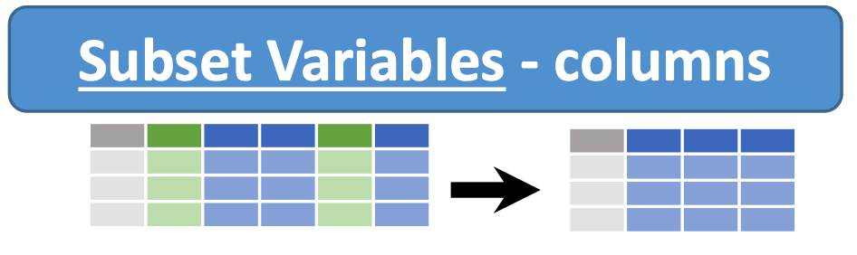

You can pass a list of columns to `[]` to select columns in that order.

- Select a single column by name

```python
df["E"]
```

```
R1        red
R2      green
R3       blue
R4      white
R5       pink
R6      brown
R7      black
R8     purple
R9     orange
R10      grey
R11    violet
R12    yellow
Name: E, dtype: category
Categories (12, object): ['black', 'blue', 'brown', 'green', ..., 'red', 'violet', 'white', 'yellow']
```

```python
df.E
```

```
R1        red
R2      green
R3       blue
R4      white
R5       pink
R6      brown
R7      black
R8     purple
R9     orange
R10      grey
R11    violet
R12    yellow
Name: E, dtype: category
Categories (12, object): ['black', 'blue', 'brown', 'green', ..., 'red', 'violet', 'white', 'yellow']
```

- Select a range of columns with specific names

```python
df[["A","C"]]
```

|  | A | C |
| --- | --- | --- |
| R1 | 0.151954 | 1 |
| R2 | 0.795155 | 2 |
| R3 | 0.466811 | 3 |
| R4 | 0.574135 | 4 |
| R5 | 0.371566 | 5 |
| R6 | 0.255201 | 6 |
| R7 | 0.339538 | 7 |
| R8 | 0.791305 | 8 |
| R9 | 0.662386 | 9 |
| R10 | 0.519865 | 10 |
| R11 | 0.234616 | 11 |
| R12 | 0.571739 | 12 |

- To subset a DataFrame while excluding specific columns

```python
df.drop(columns=["A","B"])
```

|  | C | D | E | F |
| --- | --- | --- | --- | --- |
| R1 | 1 | 62 | red | foo |
| R2 | 2 | 51 | green | foo |
| R3 | 3 | 76 | blue | foo |
| R4 | 4 | 26 | white | foo |
| R5 | 5 | 76 | pink | foo |
| R6 | 6 | 2 | brown | foo |
| R7 | 7 | 7 | black | foo |
| R8 | 8 | 15 | purple | foo |
| R9 | 9 | 27 | orange | foo |
| R10 | 10 | 99 | grey | foo |
| R11 | 11 | 70 | violet | foo |
| R12 | 12 | 46 | yellow | foo |

```python
df.drop(["C","E", "F"], axis=1)
```

|  | A | B | D |
| --- | --- | --- | --- |
| R1 | 0.151954 | 2023-01-02 | 62 |
| R2 | 0.795155 | 2023-01-03 | 51 |
| R3 | 0.466811 | 2023-01-04 | 76 |
| R4 | 0.574135 | 2023-01-05 | 26 |
| R5 | 0.371566 | 2023-01-06 | 76 |
| R6 | 0.255201 | 2023-01-07 | 2 |
| R7 | 0.339538 | 2023-01-08 | 7 |
| R8 | 0.791305 | 2023-01-09 | 15 |
| R9 | 0.662386 | 2023-01-10 | 27 |
| R10 | 0.519865 | 2023-01-11 | 99 |
| R11 | 0.234616 | 2023-01-12 | 70 |
| R12 | 0.571739 | 2023-01-13 | 46 |

### Subset Observations - rows

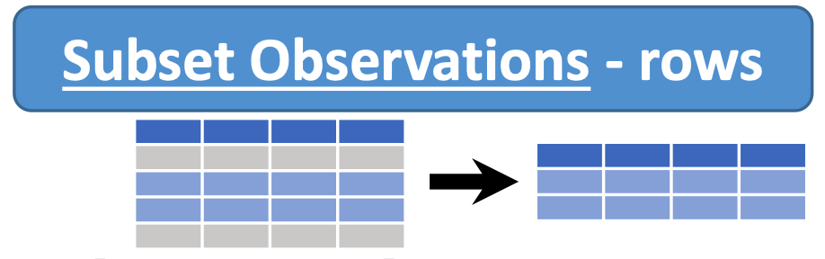

With DataFrame, slicing inside of `[]` **slices the rows**. This is provided largely as a convenience since it is such a common operation.

- Select the first row

```python
df[:1]
```

|  | A | B | C | D | E | F |
| --- | --- | --- | --- | --- | --- | --- |
| R1 | 0.151954 | 2023-01-02 | 1 | 62 | red | foo |

- Select the first five row

```python
df[:5]
```

|  | A | B | C | D | E | F |
| --- | --- | --- | --- | --- | --- | --- |
| R1 | 0.151954 | 2023-01-02 | 1 | 62 | red | foo |
| R2 | 0.795155 | 2023-01-03 | 2 | 51 | green | foo |
| R3 | 0.466811 | 2023-01-04 | 3 | 76 | blue | foo |
| R4 | 0.574135 | 2023-01-05 | 4 | 26 | white | foo |
| R5 | 0.371566 | 2023-01-06 | 5 | 76 | pink | foo |

- Select a range of rows

```python
df[3:6]
```

|  | A | B | C | D | E | F |
| --- | --- | --- | --- | --- | --- | --- |
| R4 | 0.574135 | 2023-01-05 | 4 | 26 | white | foo |
| R5 | 0.371566 | 2023-01-06 | 5 | 76 | pink | foo |
| R6 | 0.255201 | 2023-01-07 | 6 | 2 | brown | foo |

- Select the last row

```python
df[-1:]
```

|  | A | B | C | D | E | F |
| --- | --- | --- | --- | --- | --- | --- |
| R12 | 0.571739 | 2023-01-13 | 12 | 46 | yellow | foo |

- Select the last three row

```python
df[-3:]
```

|  | A | B | C | D | E | F |
| --- | --- | --- | --- | --- | --- | --- |
| R10 | 0.519865 | 2023-01-11 | 10 | 99 | grey | foo |
| R11 | 0.234616 | 2023-01-12 | 11 | 70 | violet | foo |
| R12 | 0.571739 | 2023-01-13 | 12 | 46 | yellow | foo |

- Select a range of rows

```python
df[-5:-2]
```

|  | A | B | C | D | E | F |
| --- | --- | --- | --- | --- | --- | --- |
| R8 | 0.791305 | 2023-01-09 | 8 | 15 | purple | foo |
| R9 | 0.662386 | 2023-01-10 | 9 | 27 | orange | foo |
| R10 | 0.519865 | 2023-01-11 | 10 | 99 | grey | foo |

```python
df[::-1]
```

|  | A | B | C | D | E | F |
| --- | --- | --- | --- | --- | --- | --- |
| R12 | 0.571739 | 2023-01-13 | 12 | 46 | yellow | foo |
| R11 | 0.234616 | 2023-01-12 | 11 | 70 | violet | foo |
| R10 | 0.519865 | 2023-01-11 | 10 | 99 | grey | foo |
| R9 | 0.662386 | 2023-01-10 | 9 | 27 | orange | foo |
| R8 | 0.791305 | 2023-01-09 | 8 | 15 | purple | foo |
| R7 | 0.339538 | 2023-01-08 | 7 | 7 | black | foo |
| R6 | 0.255201 | 2023-01-07 | 6 | 2 | brown | foo |
| R5 | 0.371566 | 2023-01-06 | 5 | 76 | pink | foo |
| R4 | 0.574135 | 2023-01-05 | 4 | 26 | white | foo |
| R3 | 0.466811 | 2023-01-04 | 3 | 76 | blue | foo |
| R2 | 0.795155 | 2023-01-03 | 2 | 51 | green | foo |
| R1 | 0.151954 | 2023-01-02 | 1 | 62 | red | foo |

#### Subset by condition

Extract rows that meet a logical criteria.

- Select rows where values in column C is greater than 6

```python
above_6 = df["C"] > 6 # expression over the dataframe that returns a boolean vector
print(above_6)
df[above_6]
```

```
R1     False
R2     False
R3     False
R4     False
R5     False
R6     False
R7      True
R8      True
R9      True
R10     True
R11     True
R12     True
Name: C, dtype: bool
```

|  | A | B | C | D | E | F |
| --- | --- | --- | --- | --- | --- | --- |
| R7 | 0.339538 | 2023-01-08 | 7 | 7 | black | foo |
| R8 | 0.791305 | 2023-01-09 | 8 | 15 | purple | foo |
| R9 | 0.662386 | 2023-01-10 | 9 | 27 | orange | foo |
| R10 | 0.519865 | 2023-01-11 | 10 | 99 | grey | foo |
| R11 | 0.234616 | 2023-01-12 | 11 | 70 | violet | foo |
| R12 | 0.571739 | 2023-01-13 | 12 | 46 | yellow | foo |

- Select rows where values in column D is less than or equal to 50

```python
df[df["D"]<= 50]
```

|  | A | B | C | D | E | F |
| --- | --- | --- | --- | --- | --- | --- |
| R4 | 0.574135 | 2023-01-05 | 4 | 26 | white | foo |
| R6 | 0.255201 | 2023-01-07 | 6 | 2 | brown | foo |
| R7 | 0.339538 | 2023-01-08 | 7 | 7 | black | foo |
| R8 | 0.791305 | 2023-01-09 | 8 | 15 | purple | foo |
| R9 | 0.662386 | 2023-01-10 | 9 | 27 | orange | foo |
| R12 | 0.571739 | 2023-01-13 | 12 | 46 | yellow | foo |

```python
df[df.D <= 50]
```

|  | A | B | C | D | E | F |
| --- | --- | --- | --- | --- | --- | --- |
| R4 | 0.574135 | 2023-01-05 | 4 | 26 | white | foo |
| R6 | 0.255201 | 2023-01-07 | 6 | 2 | brown | foo |
| R7 | 0.339538 | 2023-01-08 | 7 | 7 | black | foo |
| R8 | 0.791305 | 2023-01-09 | 8 | 15 | purple | foo |
| R9 | 0.662386 | 2023-01-10 | 9 | 27 | orange | foo |
| R12 | 0.571739 | 2023-01-13 | 12 | 46 | yellow | foo |

- Using `isin()` function for filtering:

```python
# select the rows with values orange and yellow
df[df["E"].isin(["yellow", "orange"])]
```

|  | A | B | C | D | E | F |
| --- | --- | --- | --- | --- | --- | --- |
| R9 | 0.662386 | 2023-01-10 | 9 | 27 | orange | foo |
| R12 | 0.571739 | 2023-01-13 | 12 | 46 | yellow | foo |

- Select rows with Column E is equal to `pink` or `blue`

```python
df[df.E.isin(["pink", "blue"])]
```

|  | A | B | C | D | E | F |
| --- | --- | --- | --- | --- | --- | --- |
| R3 | 0.466811 | 2023-01-04 | 3 | 76 | blue | foo |
| R5 | 0.371566 | 2023-01-06 | 5 | 76 | pink | foo |

- Remove duplicate rows (only considers columns).

```python
# Add a duplicate row (e.g., duplicating row "R5") to df
df = pd.concat([df, df.loc[["R5"]]])
df
```

|  | A | B | C | D | E | F |
| --- | --- | --- | --- | --- | --- | --- |
| R1 | 0.151954 | 2023-01-02 | 1 | 62 | red | foo |
| R2 | 0.795155 | 2023-01-03 | 2 | 51 | green | foo |
| R3 | 0.466811 | 2023-01-04 | 3 | 76 | blue | foo |
| R4 | 0.574135 | 2023-01-05 | 4 | 26 | white | foo |
| R5 | 0.371566 | 2023-01-06 | 5 | 76 | pink | foo |
| R6 | 0.255201 | 2023-01-07 | 6 | 2 | brown | foo |
| R7 | 0.339538 | 2023-01-08 | 7 | 7 | black | foo |
| R8 | 0.791305 | 2023-01-09 | 8 | 15 | purple | foo |
| R9 | 0.662386 | 2023-01-10 | 9 | 27 | orange | foo |
| R10 | 0.519865 | 2023-01-11 | 10 | 99 | grey | foo |
| R11 | 0.234616 | 2023-01-12 | 11 | 70 | violet | foo |
| R12 | 0.571739 | 2023-01-13 | 12 | 46 | yellow | foo |
| R5 | 0.371566 | 2023-01-06 | 5 | 76 | pink | foo |

```python
df = df.drop_duplicates()
df
```

|  | A | B | C | D | E | F |
| --- | --- | --- | --- | --- | --- | --- |
| R1 | 0.151954 | 2023-01-02 | 1 | 62 | red | foo |
| R2 | 0.795155 | 2023-01-03 | 2 | 51 | green | foo |
| R3 | 0.466811 | 2023-01-04 | 3 | 76 | blue | foo |
| R4 | 0.574135 | 2023-01-05 | 4 | 26 | white | foo |
| R5 | 0.371566 | 2023-01-06 | 5 | 76 | pink | foo |
| R6 | 0.255201 | 2023-01-07 | 6 | 2 | brown | foo |
| R7 | 0.339538 | 2023-01-08 | 7 | 7 | black | foo |
| R8 | 0.791305 | 2023-01-09 | 8 | 15 | purple | foo |
| R9 | 0.662386 | 2023-01-10 | 9 | 27 | orange | foo |
| R10 | 0.519865 | 2023-01-11 | 10 | 99 | grey | foo |
| R11 | 0.234616 | 2023-01-12 | 11 | 70 | violet | foo |
| R12 | 0.571739 | 2023-01-13 | 12 | 46 | yellow | foo |

- Randomly select n rows.

```python
df.sample(n=10)
```

|  | A | B | C | D | E | F |
| --- | --- | --- | --- | --- | --- | --- |
| R10 | 0.519865 | 2023-01-11 | 10 | 99 | grey | foo |
| R9 | 0.662386 | 2023-01-10 | 9 | 27 | orange | foo |
| R5 | 0.371566 | 2023-01-06 | 5 | 76 | pink | foo |
| R11 | 0.234616 | 2023-01-12 | 11 | 70 | violet | foo |
| R6 | 0.255201 | 2023-01-07 | 6 | 2 | brown | foo |
| R12 | 0.571739 | 2023-01-13 | 12 | 46 | yellow | foo |
| R1 | 0.151954 | 2023-01-02 | 1 | 62 | red | foo |
| R4 | 0.574135 | 2023-01-05 | 4 | 26 | white | foo |
| R7 | 0.339538 | 2023-01-08 | 7 | 7 | black | foo |
| R2 | 0.795155 | 2023-01-03 | 2 | 51 | green | foo |

- Randomly select fraction of rows.

```python
df.sample(frac=0.5)
```

|  | A | B | C | D | E | F |
| --- | --- | --- | --- | --- | --- | --- |
| R9 | 0.662386 | 2023-01-10 | 9 | 27 | orange | foo |
| R12 | 0.571739 | 2023-01-13 | 12 | 46 | yellow | foo |
| R4 | 0.574135 | 2023-01-05 | 4 | 26 | white | foo |
| R8 | 0.791305 | 2023-01-09 | 8 | 15 | purple | foo |
| R2 | 0.795155 | 2023-01-03 | 2 | 51 | green | foo |
| R10 | 0.519865 | 2023-01-11 | 10 | 99 | grey | foo |

- Select and order top n entries.

```python
df.nlargest(3, 'D')
```

|  | A | B | C | D | E | F |
| --- | --- | --- | --- | --- | --- | --- |
| R10 | 0.519865 | 2023-01-11 | 10 | 99 | grey | foo |
| R3 | 0.466811 | 2023-01-04 | 3 | 76 | blue | foo |
| R5 | 0.371566 | 2023-01-06 | 5 | 76 | pink | foo |

- Select and order bottom n entries.

```python
df.nsmallest(5, 'A')
```

|  | A | B | C | D | E | F |
| --- | --- | --- | --- | --- | --- | --- |
| R1 | 0.151954 | 2023-01-02 | 1 | 62 | red | foo |
| R11 | 0.234616 | 2023-01-12 | 11 | 70 | violet | foo |
| R6 | 0.255201 | 2023-01-07 | 6 | 2 | brown | foo |
| R7 | 0.339538 | 2023-01-08 | 7 | 7 | black | foo |
| R5 | 0.371566 | 2023-01-06 | 5 | 76 | pink | foo |

- To subset a DataFrame while excluding specific rows

```python
df.drop(index=["R1","R2","R3"])
```

|  | A | B | C | D | E | F |
| --- | --- | --- | --- | --- | --- | --- |
| R4 | 0.574135 | 2023-01-05 | 4 | 26 | white | foo |
| R5 | 0.371566 | 2023-01-06 | 5 | 76 | pink | foo |
| R6 | 0.255201 | 2023-01-07 | 6 | 2 | brown | foo |
| R7 | 0.339538 | 2023-01-08 | 7 | 7 | black | foo |
| R8 | 0.791305 | 2023-01-09 | 8 | 15 | purple | foo |
| R9 | 0.662386 | 2023-01-10 | 9 | 27 | orange | foo |
| R10 | 0.519865 | 2023-01-11 | 10 | 99 | grey | foo |
| R11 | 0.234616 | 2023-01-12 | 11 | 70 | violet | foo |
| R12 | 0.571739 | 2023-01-13 | 12 | 46 | yellow | foo |

```python
df.drop(["R2","R4","R6","R8"], axis=0)
```

|  | A | B | C | D | E | F |
| --- | --- | --- | --- | --- | --- | --- |
| R1 | 0.151954 | 2023-01-02 | 1 | 62 | red | foo |
| R3 | 0.466811 | 2023-01-04 | 3 | 76 | blue | foo |
| R5 | 0.371566 | 2023-01-06 | 5 | 76 | pink | foo |
| R7 | 0.339538 | 2023-01-08 | 7 | 7 | black | foo |
| R9 | 0.662386 | 2023-01-10 | 9 | 27 | orange | foo |
| R10 | 0.519865 | 2023-01-11 | 10 | 99 | grey | foo |
| R11 | 0.234616 | 2023-01-12 | 11 | 70 | violet | foo |
| R12 | 0.571739 | 2023-01-13 | 12 | 46 | yellow | foo |

### `filter` Function

The `filter()` function is used to **subset rows or columns** based on labels, such as column names or index labels. It is not used for filtering based on the actual values within the DataFrame but rather for subsetting by selecting specific rows or columns.

```python
DataFrame.filter(items=None, like=None, regex=None, axis=None)
```

- **items**: List of labels to filter based on.
- **like**: Substring used to filter column or row names containing the provided string.
- **regex**: Regular expression to filter column or row names.
- **axis**: Specifies whether to filter on columns (`axis=1`) or rows (`axis=0`).

Load the `cms_hospital_patient_satisfaction.csv` file from the data folder into a DataFrame named `cms`, which will be used for the following examples.

```python
cms = pd.read_csv('data/patient_satisfaction/cms_hospital_patient_satisfaction.csv')
```

1. **Filter by Specific Column Names**: Select columns “Facility Name” and “Overall Rating”.

```python
cms.filter(items=['Facility Name', 'Overall Rating'], axis=1)
```

|  | Facility Name | Overall Rating |
| --- | --- | --- |
| 0 | SCRIPPS GREEN HOSPITAL | 5 |
| 1 | ST BERNARD HOSPITAL | 2 |
| 2 | SOUTH LAKE HOSPITAL | 2 |
| 3 | MERCY HOSPITAL FORT SMITH | 3 |
| 4 | BAPTIST MEMORIAL HOSPITAL | 2 |
| 5 | ST JOSEPH REGIONAL HEALTH CENTER | 3 |
| 6 | GREENE COUNTY GENERAL HOSPITAL | 3 |
| 7 | SOUTHWEST MEMORIAL HOSPITAL | 3 |
| 8 | SENTARA GENERAL HOSPITAL | 3 |
| 9 | PIEDMONT FAYETTE HOSPITAL | 2 |
| 10 | MISSION COMMUNITY HOSPITAL | 3 |
| 11 | DOCTORS HOSPITAL | 3 |
| 12 | SUMNER REGIONAL MEDICAL CENTER | 2 |
| 13 | WHIDBEY GENERAL HOSPITAL | 3 |
| 14 | NORTHRIDGE MEDICAL CENTER | 2 |

2. **Filter by Row Index Labels**: Select rows with index labels 1,3, 5.

```python
cms.filter(items=[1,3,5], axis=0)
```

|  | ID | Facility Name | County | Hospital Type | Star Rating | No of Surveys | Response Rate | Overall Rating |
| --- | --- | --- | --- | --- | --- | --- | --- | --- |
| 1 | 140103 | ST BERNARD HOSPITAL | COOK | Acute Care Hospital | 1 | 264 | 6 | 2 |
| 3 | 40062 | MERCY HOSPITAL FORT SMITH | SEBASTIAN | Acute Care Hospital | 3 | 2506 | 35 | 3 |
| 5 | 450011 | ST JOSEPH REGIONAL HEALTH CENTER | BRAZOS | Acute Care Hospital | 3 | 1379 | 24 | 3 |

3. **Filter Columns by Substring**: Select columns whose names contain the substring `"Rating"`.

```python
cms.filter(like="Rating", axis=1)
```

|  | Star Rating | Overall Rating |
| --- | --- | --- |
| 0 | 4 | 5 |
| 1 | 1 | 2 |
| 2 | 2 | 2 |
| 3 | 3 | 3 |
| 4 | 2 | 2 |
| 5 | 3 | 3 |
| 6 | 3 | 3 |
| 7 | 4 | 3 |
| 8 | 4 | 3 |
| 9 | 2 | 2 |
| 10 | 3 | 3 |
| 11 | 4 | 3 |
| 12 | 4 | 2 |
| 13 | 3 | 3 |
| 14 | 3 | 2 |

4. **Filter Columns by Regular Expression**: Select columns whose names start with the letter `"N"`.

```python
cms.filter(regex="^N", axis=1)
```

|  | No of Surveys |
| --- | --- |
| 0 | 3110 |
| 1 | 264 |
| 2 | 1382 |
| 3 | 2506 |
| 4 | 1799 |
| 5 | 1379 |
| 6 | 114 |
| 7 | 247 |
| 8 | 619 |
| 9 | 1714 |
| 10 | 241 |
| 11 | 393 |
| 12 | 680 |
| 13 | 389 |
| 14 | 1110 |

5. **Filter Rows by Regular Expression**: Select rows whose index has two digits.

```python
cms.filter(regex="\d{2}", axis=0)
```

|  | ID | Facility Name | County | Hospital Type | Star Rating | No of Surveys | Response Rate | Overall Rating |
| --- | --- | --- | --- | --- | --- | --- | --- | --- |
| 10 | 50704 | MISSION COMMUNITY HOSPITAL | LOS ANGELES | Acute Care Hospital | 3 | 241 | 14 | 3 |
| 11 | 100296 | DOCTORS HOSPITAL | MIAMI-DADE | Acute Care Hospital | 4 | 393 | 24 | 3 |
| 12 | 440003 | SUMNER REGIONAL MEDICAL CENTER | SUMNER | Acute Care Hospital | 4 | 680 | 35 | 2 |
| 13 | 501339 | WHIDBEY GENERAL HOSPITAL | ISLAND | Critical Access Hospital | 3 | 389 | 29 | 3 |
| 14 | 50116 | NORTHRIDGE MEDICAL CENTER | LOS ANGELES | Acute Care Hospital | 3 | 1110 | 20 | 2 |

### `query()` Function

The `query()` function allows you to **filter rows** based on specific conditions applied to the values within the DataFrame. It enables writing SQL-like queries on a DataFrame using column names as variables.

```python
DataFrame.query(expr, inplace=False, **kwargs)
```

- **expr**: A string expression used for filtering.
- **inplace**: Whether to perform the operation in place.
- **kwargs**: Additional arguments (e.g., to pass column names with spaces).

#### Examples of `query()`:

1. **Filter Rows Based on a Condition**: Select rows where the value in column `"Overall Rating"` is greater than 2.

```python
cms.query("`Overall Rating` > 2")
```

|  | ID | Facility Name | County | Hospital Type | Star Rating | No of Surveys | Response Rate | Overall Rating |
| --- | --- | --- | --- | --- | --- | --- | --- | --- |
| 0 | 50424 | SCRIPPS GREEN HOSPITAL | SAN DIEGO | Acute Care Hospital | 4 | 3110 | 41 | 5 |
| 3 | 40062 | MERCY HOSPITAL FORT SMITH | SEBASTIAN | Acute Care Hospital | 3 | 2506 | 35 | 3 |
| 5 | 450011 | ST JOSEPH REGIONAL HEALTH CENTER | BRAZOS | Acute Care Hospital | 3 | 1379 | 24 | 3 |
| 6 | 151317 | GREENE COUNTY GENERAL HOSPITAL | GREENE | Critical Access Hospital | 3 | 114 | 22 | 3 |
| 7 | 61327 | SOUTHWEST MEMORIAL HOSPITAL | MONTEZUMA | Critical Access Hospital | 4 | 247 | 34 | 3 |
| 8 | 490057 | SENTARA GENERAL HOSPITAL | VIRGINIA BEACH | Acute Care Hospital | 4 | 619 | 32 | 3 |
| 10 | 50704 | MISSION COMMUNITY HOSPITAL | LOS ANGELES | Acute Care Hospital | 3 | 241 | 14 | 3 |
| 11 | 100296 | DOCTORS HOSPITAL | MIAMI-DADE | Acute Care Hospital | 4 | 393 | 24 | 3 |
| 13 | 501339 | WHIDBEY GENERAL HOSPITAL | ISLAND | Critical Access Hospital | 3 | 389 | 29 | 3 |

2. **Filter Rows Based on Multiple Conditions**: Select rows where `"Overall Rating"` is greater than 2 and the `"Response Rate"` is less than 30.

```python
cms.query("`Overall Rating` > 2 and `Response Rate` < 30")
```

|  | ID | Facility Name | County | Hospital Type | Star Rating | No of Surveys | Response Rate | Overall Rating |
| --- | --- | --- | --- | --- | --- | --- | --- | --- |
| 5 | 450011 | ST JOSEPH REGIONAL HEALTH CENTER | BRAZOS | Acute Care Hospital | 3 | 1379 | 24 | 3 |
| 6 | 151317 | GREENE COUNTY GENERAL HOSPITAL | GREENE | Critical Access Hospital | 3 | 114 | 22 | 3 |
| 10 | 50704 | MISSION COMMUNITY HOSPITAL | LOS ANGELES | Acute Care Hospital | 3 | 241 | 14 | 3 |
| 11 | 100296 | DOCTORS HOSPITAL | MIAMI-DADE | Acute Care Hospital | 4 | 393 | 24 | 3 |
| 13 | 501339 | WHIDBEY GENERAL HOSPITAL | ISLAND | Critical Access Hospital | 3 | 389 | 29 | 3 |

3. **Filter Using a String Condition**: Select rows where `"County"` is equal to `"LOS ANGELES"`.

```python
cms.query("County == 'LOS ANGELES'")
```

|  | ID | Facility Name | County | Hospital Type | Star Rating | No of Surveys | Response Rate | Overall Rating |
| --- | --- | --- | --- | --- | --- | --- | --- | --- |
| 10 | 50704 | MISSION COMMUNITY HOSPITAL | LOS ANGELES | Acute Care Hospital | 3 | 241 | 14 | 3 |
| 14 | 50116 | NORTHRIDGE MEDICAL CENTER | LOS ANGELES | Acute Care Hospital | 3 | 1110 | 20 | 2 |

4. **Filter Rows Using `or` Condition**: Select rows where `"Star Rating"` or `"`Overall Rating”` is greater than 3.

```python
cms.query("`Star Rating` > 3 or `Overall Rating` > 3")
```

|  | ID | Facility Name | County | Hospital Type | Star Rating | No of Surveys | Response Rate | Overall Rating |
| --- | --- | --- | --- | --- | --- | --- | --- | --- |
| 0 | 50424 | SCRIPPS GREEN HOSPITAL | SAN DIEGO | Acute Care Hospital | 4 | 3110 | 41 | 5 |
| 7 | 61327 | SOUTHWEST MEMORIAL HOSPITAL | MONTEZUMA | Critical Access Hospital | 4 | 247 | 34 | 3 |
| 8 | 490057 | SENTARA GENERAL HOSPITAL | VIRGINIA BEACH | Acute Care Hospital | 4 | 619 | 32 | 3 |
| 11 | 100296 | DOCTORS HOSPITAL | MIAMI-DADE | Acute Care Hospital | 4 | 393 | 24 | 3 |
| 12 | 440003 | SUMNER REGIONAL MEDICAL CENTER | SUMNER | Acute Care Hospital | 4 | 680 | 35 | 2 |

5. **Use Variable Inside `query()`**: Use a variable to filter rows dynamically.

```python
threshold = 25
cms.query("`Response Rate` > @threshold")
```

|  | ID | Facility Name | County | Hospital Type | Star Rating | No of Surveys | Response Rate | Overall Rating |
| --- | --- | --- | --- | --- | --- | --- | --- | --- |
| 0 | 50424 | SCRIPPS GREEN HOSPITAL | SAN DIEGO | Acute Care Hospital | 4 | 3110 | 41 | 5 |
| 3 | 40062 | MERCY HOSPITAL FORT SMITH | SEBASTIAN | Acute Care Hospital | 3 | 2506 | 35 | 3 |
| 7 | 61327 | SOUTHWEST MEMORIAL HOSPITAL | MONTEZUMA | Critical Access Hospital | 4 | 247 | 34 | 3 |
| 8 | 490057 | SENTARA GENERAL HOSPITAL | VIRGINIA BEACH | Acute Care Hospital | 4 | 619 | 32 | 3 |
| 12 | 440003 | SUMNER REGIONAL MEDICAL CENTER | SUMNER | Acute Care Hospital | 4 | 680 | 35 | 2 |
| 13 | 501339 | WHIDBEY GENERAL HOSPITAL | ISLAND | Critical Access Hospital | 3 | 389 | 29 | 3 |

6. **Filter Rows Based on Index**: Filter based on the index:

```python
cms.query('index == 5')
```

|  | ID | Facility Name | County | Hospital Type | Star Rating | No of Surveys | Response Rate | Overall Rating |
| --- | --- | --- | --- | --- | --- | --- | --- | --- |
| 5 | 450011 | ST JOSEPH REGIONAL HEALTH CENTER | BRAZOS | Acute Care Hospital | 3 | 1379 | 24 | 3 |